# Impact of Severe Weather Events in the U.S.

Coursera Reproducible Research Peer Assessment 2

Christopher Hair

June 27, 2017

## Synopsis

As part of the [Coursera Reproducible Research Course](https://www.coursera.org/learn/reproducible-research), the final peer assessment project is to explore the affects of severe weather events on a population’s health and economy. In this article, we examine what the impact of different types of weather events have had in the United States. We will look at the total number of injuries and fatalities along with the total cost of damages incurred for each type of event and determine which has had the greatest overall impact. The information used for the analysis comes from data collected by the U.S. National Oceanic and Atmospheric Administration (NOAA) between 1950 and 2011. All of the artifacts used in the construction of this article can be found in the [Reproducible Research Peer Assessment 2](https://github.com/Mystikweb/RepData_PeerAssessment2) repository located on [GitHub](https://github.com).

## Data Processing

### Importing Packages

```r
library(dplyr)
library(tidyr)
library(ggplot2)
library(huxtable)
```

### Preparing The Data

The snapshot data file for this course is located in the repository’s “data” folder as a CSV file compressed using the bzip2 algorithm. To start analyzing the information we need load the data into the environment and look at the structure.

```r
raw_data <- read.csv("data/repdata_data_StormData.csv.bz2")
str(raw_data)
```

```
## 'data.frame':    902297 obs. of  37 variables:
##  $ STATE__   : num  1 1 1 1 1 1 1 1 1 1 ...
##  $ BGN_DATE  : Factor w/ 16335 levels "1/1/1966 0:00:00",..: 6523 6523 4242 11116 2224 2224 2260 383 3980 3980 ...
##  $ BGN_TIME  : Factor w/ 3608 levels "00:00:00 AM",..: 272 287 2705 1683 2584 3186 242 1683 3186 3186 ...
##  $ TIME_ZONE : Factor w/ 22 levels "ADT","AKS","AST",..: 7 7 7 7 7 7 7 7 7 7 ...
##  $ COUNTY    : num  97 3 57 89 43 77 9 123 125 57 ...
##  $ COUNTYNAME: Factor w/ 29601 levels "","5NM E OF MACKINAC BRIDGE TO PRESQUE ISLE LT MI",..: 13513 1873 4598 10592 4372 10094 1973 23873 24418 4598 ...
##  $ STATE     : Factor w/ 72 levels "AK","AL","AM",..: 2 2 2 2 2 2 2 2 2 2 ...
##  $ EVTYPE    : Factor w/ 985 levels "   HIGH SURF ADVISORY",..: 834 834 834 834 834 834 834 834 834 834 ...
##  $ BGN_RANGE : num  0 0 0 0 0 0 0 0 0 0 ...
##  $ BGN_AZI   : Factor w/ 35 levels "","  N"," NW",..: 1 1 1 1 1 1 1 1 1 1 ...
##  $ BGN_LOCATI: Factor w/ 54429 levels "","- 1 N Albion",..: 1 1 1 1 1 1 1 1 1 1 ...
##  $ END_DATE  : Factor w/ 6663 levels "","1/1/1993 0:00:00",..: 1 1 1 1 1 1 1 1 1 1 ...
##  $ END_TIME  : Factor w/ 3647 levels ""," 0900CST",..: 1 1 1 1 1 1 1 1 1 1 ...
##  $ COUNTY_END: num  0 0 0 0 0 0 0 0 0 0 ...
```

[output cut: 23 more lines]

From the structure of the data we can determine that the following variables are required to perform this analysis:

| Variable | Description |
| --- | --- |
| EVTYPE | The weather event type |
| FATALITIES | The number of fatalities due to the event |
| INJURIES | The number of injuries due to the event |
| PROPDMG | The amount of property damages due to the event |
| PROPDMGEXP | The exponential amount of the property damage (i.e. M is millions) |
| CROPDMG | The amount of crop damages due to the event |
| CROPDMGEXP | The exponential amount of the crop damage (i.e. K is thousands) |

### Analyzing the Impact on Health

Using the required variables we can analyze the total injuries and fatalities to determine what types of severe weather events have had the greatest impact on the United States. For both the number of injuries and the number of fatalities by event type we can perform the following operations:

1. Group the raw data by the type of event
2. Get the total number of events for each type of event
3. Get the average amount the variable that was reported
4. Get the total amount of the variable that was reported
5. Limit the results to any events that have been reported more than 100 times

Once the previous operations are performed for both the injuries and the fatalities we can combine both data sets and reduce the results even more using the rules listed below and calculating the total amounts.

1. Take only results that have an average amount of each variable is more than 1
2. The total amount of each variable is not the same as the average amount of each variable

```r
event_injuries <- raw_data %>%
    group_by(EVTYPE) %>%
    summarise(total_events = n(),
              avg_injuries = mean(INJURIES),
              total_injuries = sum(INJURIES)) %>%
    filter(total_events > 100) %>%
    select(event_type = EVTYPE,
           total_events,
           avg_injuries,
           total_injuries)

event_fatalities <- raw_data %>%
    group_by(EVTYPE) %>%
    summarise(total_events = n(),
              avg_fatalities = mean(FATALITIES),
              total_fatalities = sum(FATALITIES)) %>%
    filter(total_events > 100) %>%
    select(event_type = EVTYPE,
           total_events,
           avg_fatalities,
           total_fatalities)

health_data <- event_injuries %>%
    inner_join(event_fatalities) %>%
    filter((avg_injuries > 1 & avg_fatalities != 0) |
               (avg_fatalities > 1 & avg_injuries != 0)) %>%
    filter(avg_injuries != total_injuries &
               avg_fatalities != total_fatalities) %>%
    select(event_type,
           total_events,
           total_injuries,
           total_fatalities)
```

```r
as_hux(health_data %>%
           mutate(total_health_related = total_injuries + total_fatalities) %>%
           arrange(desc(total_health_related)) %>%
           select("Event Type" = event_type,
                  "Total Events" = total_events,
                  "Total Injuries" = total_injuries,
                  "Total Fatalities" = total_fatalities,
                  "Total Related" = total_health_related)
       , add_colnames = TRUE) %>%
    set_bold(1, , TRUE) %>%
    set_all_borders(, , 1) %>%
    set_align(, 2:(ncol(health_data) + 1), "center") %>%
    set_number_format(0)
```

| Event Type | Total Events | Total Injuries | Total Fatalities | Total Related |
| --- | --- | --- | --- | --- |
| TORNADO | 60652 | 91346 | 5633 | 96979 |
| EXCESSIVE HEAT | 1678 | 6525 | 1903 | 8428 |
| HEAT | 767 | 2100 | 937 | 3037 |
| FOG | 538 | 734 | 62 | 796 |
| DUST STORM | 427 | 440 | 22 | 462 |

And if we visualize these totals in a plot, we see a large difference between tornadoes and other types of events.

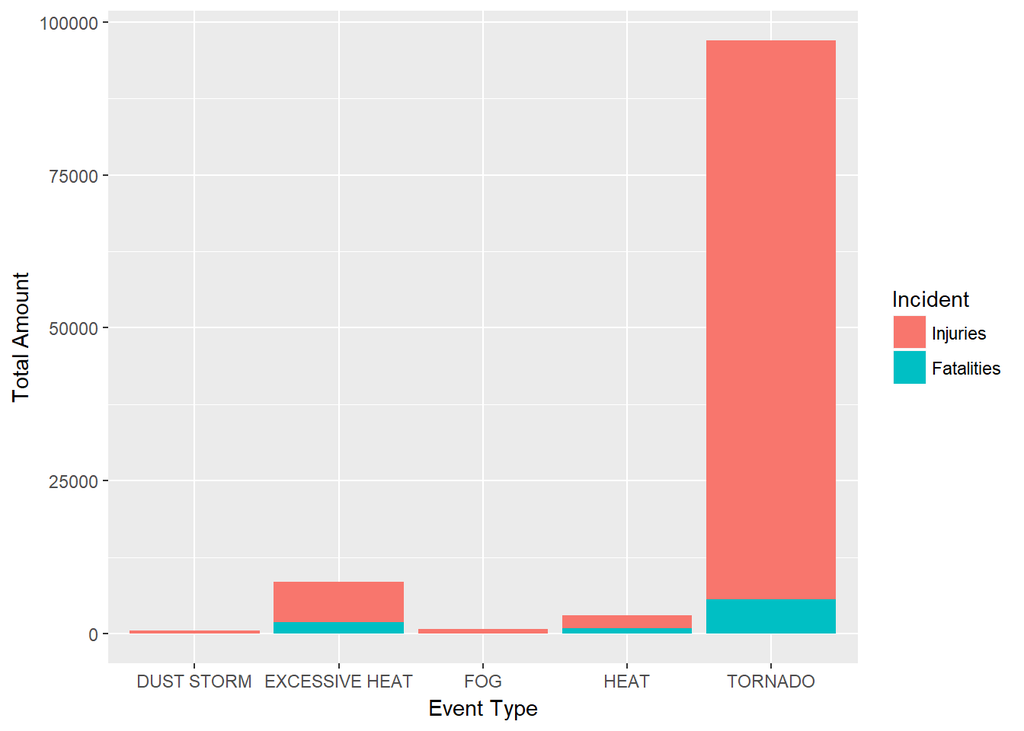

```r
health_long <- gather(health_data,
                      health_type,
                      total_amount,
                      total_injuries:total_fatalities,
                      factor_key = TRUE)

ggplot(health_long, aes(x = event_type, y = total_amount, fill=health_type)) +
    geom_bar(stat = "identity") +
    scale_fill_discrete(name = "Incident",
                        breaks = c("total_injuries", "total_fatalities"),
                        labels = c("Injuries", "Fatalities")) +
    xlab("Event Type") +
    ylab("Total Amount")
```

### Analyzing the Impact on Economy

Using the required variables we can analyze the cost of both property and crop related damages and find the totals. We can use a similar approach to the health related data accept we have another column related to exponential size of the related value. We can see below the breakdown of the possible exponential values for both the property and crop related values.

#### Property Related Exponential Values

```r
levels(raw_data$PROPDMGEXP)
```

```
##  [1] ""  "-" "?" "+" "0" "1" "2" "3" "4" "5" "6" "7" "8" "B" "h" "H" "K"
## [18] "m" "M"
```

#### Crop Related Exponential Values

```r
levels(raw_data$CROPDMGEXP)
```

```
## [1] ""  "?" "0" "2" "B" "k" "K" "m" "M"
```

*NOTE* Because there was no formal code book associated with the data file, we will make the following assumptions before performing the analysis.

**Exponential value of “H” or “h”**

The associated amount will be multiplied by 100

**Exponential value of “K” or “k”**

The associated amount will be multiplied by 1000

**Exponential value of “M” or “m”**

The associated amount will be multiplied by 1000000

**Exponential value of “B” or “b”**

The associated amount will be multiplied by 1000000000

**Exponential values that aren’t classified above**

The associated amount will be multiplied by 1

With all of the assumptions in place we can now process the data for analysis. For both the crop and property related values we can perform the following operations:

1. Use only values above 0
2. Change the exponential variable to uppercase to simplify calculating the total actual value
3. Add a new variable to hold the newly calculated value of damages based on the classification of the exponential rules
4. Group the results by the event type
5. Get the number of events for each event type
6. Get the total amount of damages incurred 7, Use only results where the number of events is more than 100
7. Take the event type, the total number of events and the total damages incurred

1. Combine both the property and crop related results by event type
2. Add a new variable to the results for the total number of events
3. Add a new variable to the results for the toal amount of damages
4. Order the results by the highest total amount of damages
5. Select only the top 5 results

```r
property_data <- raw_data %>%
    filter(PROPDMG > 0) %>%
    mutate_at(vars(PROPDMGEXP), funs(toupper)) %>%
    mutate(property_dmg = case_when(
        .$PROPDMGEXP == "H" ~ .$PROPDMG * 100,
        .$PROPDMGEXP == "K" ~ .$PROPDMG * 1000,
        .$PROPDMGEXP == "M" ~ .$PROPDMG * 1000000,
        .$PROPDMGEXP == "B" ~ .$PROPDMG * 1000000000,
        TRUE ~ .$PROPDMG * 1
    )) %>%
    group_by(EVTYPE) %>%
    summarise(property_events = n(),
              total_property_dmg = sum(property_dmg)) %>%
    filter(property_events > 100) %>%
    select(event_type = EVTYPE,
           property_events,
           total_property_dmg)

crop_data <- raw_data %>%
    filter(CROPDMG > 0) %>%
    mutate_at(vars(CROPDMGEXP), funs(toupper)) %>%
    mutate(crop_dmg = case_when(
        .$CROPDMGEXP == "H" ~ .$CROPDMG * 100,
        .$CROPDMGEXP == "K" ~ .$CROPDMG * 1000,
        .$CROPDMGEXP == "M" ~ .$CROPDMG * 1000000,
        .$CROPDMGEXP == "B" ~ .$CROPDMG * 1000000000,
        TRUE ~ .$CROPDMG * 1
    )) %>%
    group_by(EVTYPE) %>%
    summarise(crop_events = n(),
              total_crop_dmg = sum(crop_dmg)) %>%
    filter(crop_events > 100) %>%
    select(event_type = EVTYPE,
           crop_events,
           total_crop_dmg)

economy_data <- property_data %>%
    inner_join(crop_data, by = c("event_type")) %>%
    mutate(total_damages = total_property_dmg + total_crop_dmg,
           total_events = property_events + crop_events) %>%
    arrange(desc(total_damages)) %>%
    top_n(5)
```

Using these results we can look at the total amount of damages incurred in a tabular format. We can see below that tornadoes has generated the most total damages.

```r
as_hux(economy_data %>%
           select("Event Type" = event_type,
                  "Crop Events" = crop_events,
                  "Crop Damages" = total_crop_dmg,
                  "Property Events" = property_events,
                  "Property Damages" = total_property_dmg,
                  "Number of Events" = total_events,
                  "Total Damages" = total_damages)
       , add_colnames = TRUE) %>%
    set_bold(1, , TRUE) %>%
    set_all_borders(, , 1) %>%
    set_align(, 2:ncol(economy_data), "center") %>%
    set_number_format(0)
```

| Event Type | Crop Events | Crop Damages | Property Events | Property Damages | Number of Events | Total Damages |
| --- | --- | --- | --- | --- | --- | --- |
| TORNADO | 1496 | 414953270 | 39036 | 56937160779 | 40532 | 57352114049 |
| HAIL | 9375 | 3025954473 | 23047 | 15732267543 | 32422 | 18758222016 |
| FLASH FLOOD | 2112 | 1421317100 | 20568 | 16140812067 | 22680 | 17562129167 |
| TSTM WIND | 3447 | 554007350 | 60487 | 4484928495 | 63934 | 5038935845 |
| THUNDERSTORM WIND | 946 | 414843050 | 43269 | 3483121284 | 44215 | 3897964334 |

And if we visualize these totals in a plot, we see a large difference between tornadoes and other types of events.

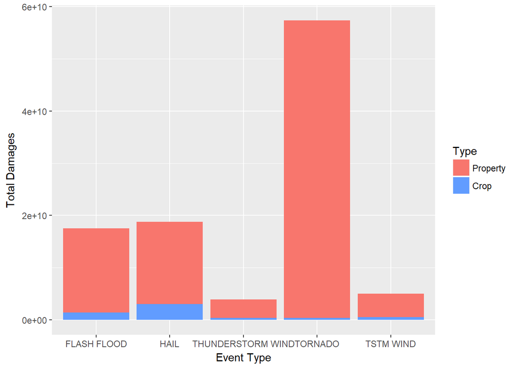

```r
economy_long <- gather(economy_data,
                       dmg_type,
                       total_dmgs,
                       total_property_dmg:total_crop_dmg,
                       factor_key = TRUE)

ggplot(economy_long, aes(x = event_type, y = total_dmgs, fill=dmg_type)) +
    geom_bar(stat = "identity") +
    scale_fill_discrete(name = "Type",
                        breaks = c("total_property_dmg", "total_crop_dmg"),
                        labels = c("Property", "Crop")) +
    xlab("Event Type") +
    ylab("Total Damages")
```

## Results

To summarize, in this article we were tasked through our project to analyze the effects different types of severe weather events have had on the United States. We used a snapshot of data collected by the U.S. National Oceanic and Atmospheric Administration (NOAA) between 1950 and 2011. After analyzing the information related to the total number of injuries and fatalites along with the total amount of damages incurred to property and crops we were able to conclude the result. The severe weather event that has had the largest impact on both the health and economy of the United States have been tornadoes, and in both cases tornadoes have caused a much higher results than any other type of severe weather event.